# Habitat association and coexistence of endemic and introduced ant species in the Galápagos Islands - WAUTERS - 2016 - Ecological Entomology - Wiley Online Library

[Ecological Entomology](https://onlinelibrary.wiley.com/journal/13652311)

[Volume 41, Issue 1](https://onlinelibrary.wiley.com/toc/13652311/2016/41/1)

[figure not shown]

Original Article

Full Access

# Habitat association and coexistence of endemic and introduced ant species in the Galápagos Islands

[NINA WAUTERS](https://onlinelibrary.wiley.com/action/doSearch?ContribAuthorStored=WAUTERS%2C+NINA)

[WOUTER DEKONINCK](https://onlinelibrary.wiley.com/action/doSearch?ContribAuthorStored=DEKONINCK%2C+WOUTER)

[FREDERIK HENDRICKX](https://onlinelibrary.wiley.com/action/doSearch?ContribAuthorStored=HENDRICKX%2C+FREDERIK)

[HENRI W. HERRERA](https://onlinelibrary.wiley.com/action/doSearch?ContribAuthorStored=HERRERA%2C+HENRI+W)

[DENIS FOURNIER](https://onlinelibrary.wiley.com/action/doSearch?ContribAuthorStored=FOURNIER%2C+DENIS)

Correspondence: Denis Fournier, Evolutionary Biology and Ecology, Université Libre de Bruxelles, Avenue F.D. Roosevelt, 50, CP 160/12, 1050 Brussels, Belgium. E‐mail:

First published: 21 September 2015

https://doi.org/10.1111/een.12256

Citations: 4

Associate Editor: Simon Robson

## Abstract

1. We investigated ant communities in all main vegetation zones of the model island of Santa Cruz in the Galápagos archipelago (155 collection points, spread over 21 sites; 28 ant species collected), and evaluated the distribution, coexistence, and effect of environmental factors in a community composed of endemic, probably endemic, and introduced ants of the New World and exotic origin.

3. The present study confirmed the predominance of two dominant invasive species, *Solenopsis geminata* Fabricius and *Wasmannia auropunctata* Roger, whose abundances are negatively correlated. The abundance of *S. geminata* is positively correlated with the overall species richness, and with the proportion of other introduced species. The presence of both invasive ants is associated with a low evenness of ant communities.

4. The present study (i) stresses the dominance of introduced species and the relative resistance of endemic species, (ii) highlights the on‐going processes of species introductions and (iii) points out the need for adequate monitoring and conservation of the pristine and threatened environments that constitute the Galápagos Islands.

## Introduction

Oceanic islands have long been used as model systems and open sky laboratories for research in ecology, evolution, biogeography, and conservation (MacArthur & Wilson, 1967; Whittaker & Fernández‐Palacios, 2007). Insular habitats are particularly sensitive to the establishment of alien species because they have low functional redundancy, simpler food webs, and a large fraction of their species are introduced (O'Dowd *et al*., 2003). Discovered in 1535 and remained almost unsettled until the 1830s, the Galápagos Islands have high endemism levels and are recognised as a World Heritage Site and a biodiversity hotspot (Myers *et al*., 2000; Walsh & Mena, 2013). The principal threat to the terrestrial ecosystems of the Galápagos archipelago is the introduction of alien species (Tye *et al*., 2002; Walsh & Mena, 2013; Benitez‐Capistros *et al*., 2014).

Amongst invasive species, ants are considered as dramatic invaders, both on islands and continents (Suarez *et al*., 2010), and many studies have shown their negative impact on native ant communities, both on mainland (Porter & Savignano, 1990; Holway *et al*., 2002a; Walker, 2006; Stuble *et al*., 2009) and island biotas (Wetterer *et al*., 2001, 2006). However, the relative importance of environmental factors and competition once settled has seldom been examined in ant invasions.

Communities of ants, whether they are native or introduced, can be shaped by a variety of either biotic or abiotic factors. At a large spatial scale, climatic variables and habitat productivity play an important role in determining the distribution and coexistence of ant species (Kaspari *et al*., 2000). Temperature, rainfall, and humidity are the most influential variables (primary productivity being a function of rainfall and solar radiation) as they determine the foraging activity and control the development of eggs, larvae, and pupae (Kaspari, 2000). At a smaller spatial scale, inter‐specific competition is often considered as the main structuring force of ant communities (Parr & Gibb, 2010; but see Cerdá *et al*., 2013). Competition is thought to result in ant dominance hierarchies, usually structured by ecologically and behaviourally dominant territorial ants (Wetterer *et al*., 1999; Gibb, 2005). However, dominant species are not very widespread around the world, and subdominant species (non‐territorial but aggressive species when defending or taking over food resources) can act as dominant species (Cerdá *et al*., 2013). Dominance mechanisms include numerical superiority, inter‐specific aggression, competitive exclusion at food resources, and distinctive foraging strategies for accessing resources or avoiding dominant species (Parr & Gibb, 2010). However, a recent review showed that several factors mediate the importance of competition, and that ant communities structure is rather shaped by a complex network of interactions involving abiotic and biotic factors (Cerdá *et al*., 2013).

The present study examines the organisation patterns of ant communities – composed of endemic, probably endemic and introduced species – in one of the most preserved archipelagos on Earth, the Galápagos Islands. The ant fauna of the archipelago is composed of relatively few species (51 species; Herrera *et al*., 2014) most of which have been introduced. We aim to (i) identifying the habitat preferences and repartition of endemic, probably endemic, and introduced ant species in a model island of the archipelago; (ii) determining the importance of environmental variation and competition in the structuring of ant communities, and (iii) observing the relations between introduced, probably endemic and endemic species, focusing on the dominant ants.

## Methods

### *Study area*

From volcanic origin, the Galápagos Islands are located 972 km East off the Ecuadorian Coast and are constituted of 18 main islands and over 100 islets and rocks (Snell *et al*., 1995; Tye *et al*., 2002). Santa Cruz is the second largest island of the archipelago (986 km<sup>2</sup>) and peaks at 864 m (Wiggins & Porter, 1972) (Fig. 1). It is the most densely populated island, with 14% of its area that has been altered by human activities (Watson *et al*., 2009). We focused our study on this island considered as a representative of the other islands of the archipelago as it hosts most of the environment types described (Tye & Francisco‐Ortega, 2011). The island is divided into five vegetation zones: (i) littoral zone, dominated by shrubs and small trees, including mangroves and other salt‐tolerant plant species; (ii) arid zone, which contains xerophytic vegetation, mostly low scrub and cactus species of the genus *Opuntia*; (iii) transition zone with a mixture of vegetation from lower and higher zones, but with significant tree cover; (iv) humid zone dominated by the endemic tree genus *Scalesia*; and (v) very humid zones composed of the endemic tree *Miconia robinsonia*, sedges and ferns. Santa Cruz also presents a wide variety of human‐disturbed areas: towns, villages, pastures, and agriculture zone (Watson *et al*., 2009). All sampled sites were grouped into four categories of habitats based on humidity and disturbance (von Aesch & Cherix, 2005): natural humid areas (NH) (*Miconia, Scalesia,* pampa zones and lagoon), natural dry areas (ND) (littoral, arid and transition zones), disturbed dry areas (DD) (urban zones), and disturbed humid areas (DH) (agricultural zones: plantations, pastures, and forest edges) (see Table S1).

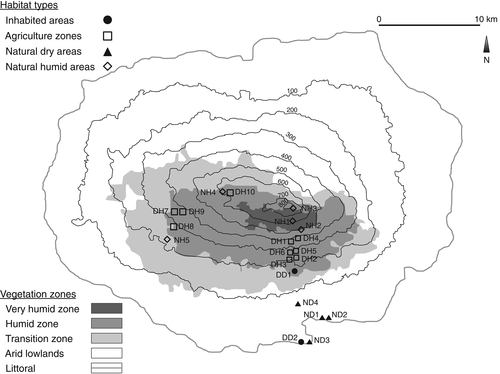

**Figure 1**

Distribution map of the sites where ants were sampled on Santa Cruz Island. Contour lines indicate altitude in metres and the scale of grey indicates the vegetation zones. DD, disturbed dry areas; DH, disturbed humid areas; ND, natural dry areas; NH, natural humid areas.

### *Ant sampling and identification*

Ants were collected during three sampling missions (February–April 2010, 2011, and 2012), in the rainy season. We collected samples at 21 sites covering all the major vegetation zones and all types of anthropogenic disturbed areas (Wauters *et al*., 2014). At each sampling site, a transect of eight pitfall traps (PF) was set up, each trap being separated by 2 m, yielding a total of 168 samples. According to Ward *et al*. (2001), spacing between traps was chosen as a compromise between intensive sampling and minimising interference between pitfall traps and field conditions. Traps were emptied after 14 days. Samples flooded by rain or destroyed by animals or human activities were discarded from our analysis. In total, 155 pitfalls out of 168 were collected and investigated. Sites are distributed into habitats categories: natural humid areas (NH; 5 sites, 40 PF), natural dry areas (ND; 4 sites, 32 PF), human‐disturbed dry areas (DD; 2 sites, 16 PF), and disturbed humid areas (DH; 10 sites, 80 PF) (see Table S1). In order to verify the extent of the inter‐annual variation in species proportion, we sampled three sites yearly: NH4 (*Scalesia* forest), NH2 (*Miconia* forest), and DH6 (mixed coffee–banana plantation). As there were only small variations (see Results), all samples collected during the three sampling missions were pooled.

Ants were identified using Bolton's key to ant genera (Bolton, 1994) and comparisons to identified material deposited at the Invertebrates Collection of the Charles Darwin Research Station (ICCDRS), also available on AntWeb (http://www.antweb.org/galapagos.jsp). The invasion status of the ant species (endemic species, i.e. only found in the archipelago; widespread New World species and Old World exotic species) was based on literature (Emery, 1893; Clark *et al*., 1982; Lubin, 1984; Pezzati *et al*., 1998; Pacheco *et al*., 2007; Herrera & Longino, 2008; Herrera & Causton, 2010; Lattke, 2011; Herrera *et al*., 2014) and a database (Herrera & Roque‐Álbelo, 2014). We treated all widespread New World species and Old World exotic species as introduced to the Galápagos Islands. We added two categories (probably endemic species and probably introduced species) that included the species whose status remains uncertain and needs further investigations. The studied material was deposited at the ICCDRS and the Royal Belgian Institute of Natural Sciences (RBINS).

### *Environmental variables*

Each of the 21 sampling sites were geolocalised by GPS and the following environmental variables were measured on the area of the transect (18 × 4 m<sup>2</sup> rectangle): altitude, leaf litter thickness (using a graduated rule), vegetation height and % cover on the ground (separately for trees over 3 m height, shrubs under 3 m, ferns, grass, and other plants), and total vegetation cover (%). The ground cover of the vegetation was estimated by taking pictures and analysing the areas covered by a specific type of vegetation using *ImageJ* (Rasband, 1997–2014). The mean height of a vegetation type was estimated in the field using a tape measure. Rainfall and temperature data were not available for the majority of the sites. Normality was tested using Shapiro–Wilk statistics and homogeneity of variances using Levene's test. Non‐parametric correlations were performed, and Spearman's rho calculated to assess for any relationship between variables. Variables correlated with one another were suppressed.

### *Diversity estimates and general statistics*

From the many indices used in diversity surveys, a set of species richness and evenness measures were selected (Routledge, 1979; Mao & Colwell, 2005). Shannon's index along with *S* (number of species) were calculated both at the sample and locality level. Piélou's index of evenness and the Simpson index of diversity (1 − *D*) provided estimates of species evenness. The Chao2 non‐parametric estimator of total richness was used to account for the variation in sampling effort across habitat types. Comparisons of species abundances at the sites sampled each year were performed using a χ<sup>2</sup> test. The composition of ant species from different habitats was examined using detrended correspondence analysis (DCA). Global and pairwise analysis of similarities (anosim) was used to investigate global and pairwise differences between habitats types (Bray‐Curtis similarity, 999 permutations). Species occurrences were used for all analyses except for the relations between the abundance of dominant ant species and diversity indices investigated through Spearman rank‐test correlations. All analyses were conducted in *R* Software (R Development Core Team, 2013).

### *Co‐occurrence of ant species*

Co‐occurrence of species was examined using the *EcoSim* software (Ellison, 2000; Gotelli & Ellison, 2002) and were analysed at the habitat scale using the fixed‐fixed model and at the local scale using the fixed‐equiprobable model (Ellison, 2000; Gotelli & Ellison, 2002). The *C*‐score index (Stone & Roberts, 1990) was compared with simulated matrices from 5000 randomly constructed communities. A larger *C*‐score corresponds to lesser average pairwise species co‐occurrences. Thus a competitively structured assemblage should have a *C*‐score significantly larger than expected by chance (Gotelli & Arnett, 2000). At a local scale, a meta‐analysis was used to determine overall co‐occurrence patterns for each habitat (Gotelli & Ellison, 2002). The *C*‐score was calculated for each sample, and the standardised effect size was calculated for each habitat. In the case of communities with little co‐occurrence, the hypothesis in the upper tail should frequently be rejected, and the average effect size should be significantly greater than zero.

## Results

### *Community analysis*

Variation in species proportions between years was non‐significant for the two natural sites (NH2 and NH4), and for the disturbed site (DH6) between 2010 and 2011. Data of 2012 in DH6 showed a significant difference in species proportion with 2010 and 2011 (χ<sup>2</sup>, *P* < 0.01 and *P* < 0.05, respectively) that can be explained by the high abundance of a single species (*Odontomachus bauri* Emery) in 2012.

A total of 8505 ants (687 occurrences), belonging to four subfamilies, 18 genera and 28 species, were collected by pitfall traps. We sampled 70.0% of all ant species ever collected on Santa Cruz Island (40 spp.), and added two new species records for the island (*Monomorium* sp. nr. *pharaonis and Tetramorium caldarium* Roger). The genus *Nylanderia* awaits revision in Galápagos Islands (H. W. Herrera, unpublished); however, we were able to identify the species *N. steinheili* Forel. Other unidentified species (or group of species) were grouped as *Nylanderia* spp. We collected one endemic species, three probably endemic species, and two probably introduced species.

Table 1. List of sampled species classified by invasion statuses and their frequencies (occurrences divided by the number of samples) in each habitat type

[output not shown]

- DH, disturbed humid; DD, dry disturbed; NH, natural humid; ND, natural dry.
- Statuses are given according to: (Emery, 1893; Clark *et al*., 1982; Lubin, 1984; Pacheco & Vasconcelos, 2007; Herrera & Longino, 2008; Herrera & Causton, 2010; Lattke, 2011; Heraty & Herrera, 2014; Herrera *et al*., 2014); and AntWeb (http://www.antweb.org/galapagos.jsp).

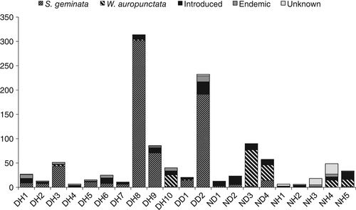

**Figure 2**

Invasion status composition of each sampling site. Values represent the mean number of individuals per pitfall trap for each habitat type. DH, disturbed humid; DD, disturbed dry; ND, natural dry areas; NH, natural humid areas. Introduced species are displayed in black; thin stripes represent *Solenopsis geminata* and thick stripes *Wasmannia auropunctata* abundances*.* Endemic and probably endemic species are displayed in dark grey and undetermined status in light grey.

Three other worldwide pests were present on Santa Cruz Island: *Paratrechina longicornis* Latreille (nine occurrences), *Monomorium* sp. nr. *pharaonis* and *Pheidole megacephala* Fabricius. The last two were only observed on one occasion each. *Paratrechina longicornis* and *P. megacephala*, observed for the first time in natural areas on Santa Cruz Island, were restricted to the arid zone, and *M*. sp. nr. *pharaonis* was found on the side of the main road of Santa Cruz.

Introduced species (New World widespread and Old World exotic, excluding *S. geminata* and *W. auropunctata*) constituted 51.2% of the total of occurrences and were present in 94.2% of the samples. Probably introduced species constituted 11.3% of total occurrences and were present in 40.0% of samples. Finally, endemic or probably endemic constituted 12.6% of total occurrences and were present in 54.2% of the samples. None of the sites was free of introduced species, but all the habitat types hosted endemic or probably endemic species. The only endemic species (*Camponotus planus* Smith) was mostly found in dry, disturbed habitats (88.9% of its occurrences) and natural dry areas (11.1%). Probably endemic species were mainly found in humid areas, disturbed (50.6% of their occurrences) or natural (42.6%). Introduced species (excluding *S. geminata* and *W. auropunctata*) were more common in disturbed humid habitats (40.4% of their occurrences) and natural humid habitats (34.2%), but remained widespread in other habitats (from 16.4% and 8.9% in natural dry and dry disturbed habitats, respectively) (for details on the most common species habitat preferences see below).

The detrended correspondence analysis (DCA) applied to data normalised per sample illustrates the habitat preferences of the six more abundant species in term of individuals. The tropical fire ant *S. geminata* was associated with disturbed areas (dry and humid), the little fire ant *W. auropunctata* was more commonly found in the arid zone, and three other species (*Nylanderia* sp*., Cyphomyrmex rimosus* Spinola, and *S. gnoma*) were more associated with a natural humid habitat. The introduced ant *S. louisianae* was associated with a humid habitat, both disturbed and natural. A global anosim (*R* = 0.48, *P* = 0.001) showed a differentiation between habitats, confirmed by a significant pairwise difference. All habitats were clearly differentiated (all 0.48 < *R* < 0.76, all *P* < 0.050), except for the separation between natural dry and disturbed dry habitats, which was only marginally significant (*R* = 0.57, *P* = 0.062), and the non‐significant separation between the two disturbed areas (dry and humid) (Fig. 3). One disturbed humid site (DH10) had a composition similar to the natural arid sites.

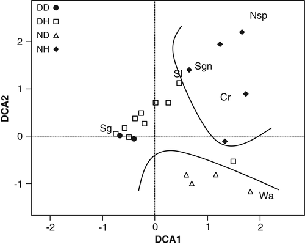

**Figure 3**

Detrended correspondence analysis ordination of ant communities. Sites are displayed according to habitat type. DH, disturbed humid; DD, disturbed dry; ND, natural dry areas; NH, natural humid areas. The six most abundant species in terms of individuals are indicated by their initials: *Solenopsis geminata* (Sg), *Wasmannia auropunctata* (Wa), *Nylanderia sp.* (Nsp); *Cyphomyrmex rimosus* (Cr), *Strumigenys louisianae* (Sl), and *Solenopsis gnoma* (Sgn*)*. Significant groups identified by pairwise anosim are displayed in black lines.

### *Co‐occurrence of ant species*

At the habitat scale, the observed *C*‐score calculated with the fixed‐fixed model for disturbed humid areas was significantly larger than expected *C*‐scores generated by null models (observed index *I<sub>obs</sub>* = 2.431, mean of simulated indices *I<sub>sim</sub>* = 2.323, *P* = 0.008). However, natural areas (humid and dry) and disturbed dry areas appeared not to be different from random expectations (NH: *I<sub>obs</sub>* = 0.625, *I<sub>sim</sub>* = 0.607, *P* = 0.274; ND: *I*<sub>*ob*s</sub> = 0.593, *I<sub>sim</sub>* = 0.583, *P* = 0.056; DD: *I<sub>obs</sub>* = 0.176, *I<sub>sim</sub>* = 0.176, *P* = 1). At a local scale, the analysis showed that ant communities are also randomly assembled (i.e. the standardised effect size did not differ from zero and the null hypothesis was not rejected in the upper tail) (Table 2).

Table 2. Meta‐analysis for effect sizes for co‐occurrence patterns at the global and the local scale for each habitat using the fixed‐equiprobable model

| Habitat | Lower tail | Upper tail | Effect size | *t* | *p* |
| --- | --- | --- | --- | --- | --- |
| Disturbed humid | 9 (1) | 3 (0) | −0.637 ± 1.09 | 2.026 | 0.068 |
| Natural arid | 3 (0) | 1 (0) | −0.265 ± 0.512 | 1.036 | 0.377 |
| Natural humid | 4 (2) | 5 (0) | −0.536 ± 1.499 | 1.073 | 0.315 |
| Disturbed dry | 2 (1) | 0 (0) | −1.727 ± 0.334 | 7.318 | 0.087 |

- Numbers in the lower and upper tails indicate the number of assemblages for which the *C*‐score was, respectively, less than or greater than predicted by the null model. The number in parentheses indicates the number of assemblages with significant patterns (*P* < 0.05, one‐tailed test). A one‐sample *t*‐test was used to test the hypothesis that the standardized effect size (SES) for the set of assemblages does not differ from zero. Communities with little co‐occurrence should frequently reject the null hypothesis in the upper tail, and the meta‐analysis pattern would be an effect size significantly greater than zero.

### *Relation of two dominant invasive ants with other species*

Two ants were largely dominant, the tropical fire ant *S. geminata* (90 occurrences, 4437 individuals) and the little fire ant *W. auropunctata* (45 occurrences, 1562 individuals). For both species, the number of individuals in samples (abundance) and the relative proportion with regard to other species were highly correlated (both *p* < 0.001), so we only discuss the abundance. The two species were found in all habitat types, but the abundance of *S. geminata* was the lowest in the natural humid area. It was significantly higher in natural dry areas, and significantly higher still in disturbed areas (dry and humid) (Wilcoxon's rank tests, all *P* < 0.010)*. Wasmannia auropunctata's* proportion and abundance were significantly higher in natural dry areas compared with other habitats (Wilcoxon's rank tests, all *P* < 0.050).

We also tested the correlations between the number of individuals (abundance) and relative proportion of the two invasive ants, and the diversity indices and abundance of endemic and probably endemic and introduced species (all introduced ant species except *S. geminata* and *W. auropunctata*) (Table 3). The proportion and abundance of *S. geminata* was negatively correlated with all the diversity indices (all *P* < 0.010), except a positive correlation with the species richness (Spearman's rank correlation, *r<sub>S</sub>* = 0.30, *P* < 0.001). The abundance of *S. geminata* was positively correlated with the abundance of other introduced species. The abundance of *W. auropunctata* was also negatively correlated with Piélou's index, and its proportion was positively correlated with the species richness. Both species' relative abundances in samples were negatively correlated (*r<sub>S</sub>* = −0.27, *P* < 0.001).

Table 3. Spearman‐Rho statistics and their probabilities for the biodiversity indices (species richness, estimated total species richness indicator Chao2, Shannon–Wiener, and Piélou's evenness), the abundance of endemic and probably endemic species, the abundance of introduced species (excluding the two ants *Solenopsis geminata* and *Wasmannia auropunctata*), and the abundance and proportion of *S. geminata* and *W. auropunctata*

| Indices | Abundance *S. geminata* | Abundance *W. auropunctata* | Proportion *S. geminata* | Proportion *W. auropunctata* |
| --- | --- | --- | --- | --- |
| Specific richness | 0.30*** | 0.06NS | 0.08NS | 0.25** |
| Shannon–Wiener | −0.30*** | −0.13NS | −0.28** | 0.10NS |
| Piélou | −0.57*** | −0.26** | −0.49*** | −0.16NS |
| Abundance (probably) endemic species | −0.05NS | 0.12NS | −0.10NS | 0.09NS |
| Abundance introduced species | 0.25*** | 0.11NS | 0.18* | 0.11NS |

- NS: *P* > 0.05; *: *P* < 0.05; **: *P* < 0.01; ***: *P* < 0.001.

## Discussion

This work provided a detailed overview of the ant community of Santa Cruz Island, Galápagos, and its structuring factors. Other than Santa Cruz Island, ant communities in Galápagos *per se* have only been studied on the island of Floreana (Pezzati *et al*., 1998; von Aesch & Cherix, 2005). Both studies revealed that Floreana hosts 24 ant species, among which 20 were present on Santa Cruz. *Solenopsis geminata* and *W. auropunctata* were also dominant species. Checklists and studies conducted on other islands such as Santiago (Lubin, 1984, 1985), Marchena (Roque‐Albelo *et al*., 2000), Santa Fé (Abedrabbo, 1994), and Baltra (Herrera & Causton, 2010) mentioned a similar pattern, with tramp ants largely dominant and the presence of one or both fire ants (Herrera & Causton, 2008). In terms of ant fauna and environment types as previously mentioned, Santa Cruz was, therefore, a good representative of other islands of the Galápagos archipelago.

### *Habitat and repartition of endemic and introduced species*

Higher species richness in disturbed areas may seem counterintuitive, as it has been shown in many studies that species richness is higher in natural undisturbed habitats (Dornelas, 2010), for litter arthropods (Migge‐Kleian *et al*., 2007), and arboreal ants (Floren & Linsenmair, 2001). However this pattern varies, and leaf‐litter ant richness has also been showed to increase with a disturbance in a tropical forest (e.g. Lawton *et al*., 1998). Island biotas, in particular, may be characterised by an increase in species richness as the number of non‐native species becoming naturalised is greater than the number of native species becoming extinct (Sax *et al*., 2002; Boyer, 2008). The non‐native species may then form a stable system (Brown *et al*., 2001). In the Galápagos Islands, the majority of ant species are introduced ‘tramp’ ants. This result has also been observed in New Caledonia (Berman *et al*., 2013), Polynesia (Morrison, 2008), the Juan Fernández archipelago (Ingram *et al*., 2006), and Hawaii (Krushelnycky *et al*., 2005), the last two hosting no native species. The Pacific islands are known as recipients of most of the transferred ant species (McGlynn, 1999).

Sites were clustered in three groups of ant communities based on habitat type (determined by disturbance and humidity levels), except for one disturbed humid site (DH10) that presented an ant composition closer to natural arid sites. Although DH10 was located in the *Scalesia* zone, the sampling took place in a locally open and dry area, which might account for the difference in species composition. Disturbance is known to have a structuring effect on insular ant communities (Hoffmann & Andersen, 2003; Berman *et al*., 2013), sometimes obscuring the effects of other factors such as island size (Rizali *et al*., 2010). Disturbance can also facilitate the colonisation by dominant ants (Gibb & Hochuli, 2003; Fitzgerald & Gordon, 2012). Many studies show that ant communities are also influenced by a variety of other factors such as elevation, both in arid and humid ecosystems (McCoy, 1990; Sanders *et al*., 2003b), and vegetation cover (Achury *et al*., 2012). The tree cover, in particular, is linked to the milieu openness (i.e. the part of the landscape not enclosed by trees), which influences ant species composition (Uhl & Vieira, 1989; Berman *et al*., 2013).

### *Coexistence of ant species*

Reduced co‐occurrences of ant species at the habitat scale were also found for other oceanic islands such as the Florida Keys and Tokelau (Cole, 1983; Lester *et al*., 2009). It is usually accepted that if competition acts and affects species distribution, co‐occurrence patterns should be non‐random in undisturbed assemblages, as opposed to random patterns in disturbed assemblages (Badano *et al*., 2005; Sanders *et al*., 2007; Ward & Beggs, 2007). We found opposite patterns in this study, the negative species co‐occurrences only happening in disturbed humid areas. Negative species co‐occurrences cannot unambiguously be attributed to competitive interactions: they also can result from nestedness patterns (i.e. ordered variation in species richness and incidence, consequence of environmental variation, and species characteristics) (Ulrich & Gotelli, 2007).

Ant communities are usually competitively structured at the small scale (Levings & Traniello, 1981; Retana & Cerdá, 1995); however, Gotelli and Ellison (2002) observed in New England the same pattern of random species co‐occurrences as we discovered in Santa Cruz. In some cases, competitively structured assemblages show only random species distribution patterns because the type of data used (pitfall trap catches) masks competitive interactions (Bartha *et al*., 1995).

A more likely explanation for the general lack of species segregation is that invasive species might have disassembled the ant fauna, causing random patterns of species occurrences. Invasive species are known to have a negative impact on other ants through the exploitation of resources and interference competition (Holway *et al*., 2002b). This pattern has been observed for *S. invicta* Buren (Gotelli & Arnett, 2000) and *Linepithema humile* Mayr (Sanders *et al*., 2003a). In the Galápagos Islands, *S. geminata* and *W. auropunctata* might be responsible for the community disassembly observed. Finally, the lack of observed competition might result from the fact that the Galápagos Islands constitute a harsh environment and an extremely dynamic system, with large annual and exceptional variations in climate (e.g. long‐lasting El Niño events) (Roque‐Albelo, 2008; Trueman & d'Ozouville, 2010). Indeed, harsh environments act as a habitat filter, limiting the pool of potential colonists and thus altering the co‐occurrence patterns (Gotelli & Ellison, 2002).

### *Dominance of S. geminata and W. auropunctata*

Two studies showed that *W. auropunctata* was dominant in the 1970s and the 1980s on Santa Cruz Island whereas *S. geminata* was only marginally present (Clark *et al*., 1982; Lubin, 1984). Today, the tropical fire ant *S. geminata* is the dominant species on Santa Cruz in all disturbed areas, the little fire ant *W. auropunctata* being restricted to some of the most pristine sites, dry or humid. We observed a negative correlation between the abundance of *S. geminata* and *W. auropunctata*, suggesting either different habitat preferences or competition between the two species, the first being less likely as *W. auropunctata* used to live in the sites now colonised by *S. geminata*. These sites were relatively unchanged since the last sampling effort (Watson *et al*., 2009), disfavouring the hypothesis of an environmental change favouring *S. geminata*. The latter is even considered as the only successful competitor of *W. auropunctata* in the Galápagos ant fauna (Lubin, 1984; von Aesch & Cherix, 2005), which suggests that this species progressively replaced *W. auropunctata*, either by interference or by exploitative competition. The second explanation seems more probable as *S. geminata* showed very low aggression levels towards other species (Morrison, 1996; von Aesch & Cherix, 2005).

### *Alien ant species in the Galápagos Islands*

The alteration of habitats has been increasing on the Galápagos archipelago since the 1960s as a result of the development of mass tourism (de Groot, 1983; Benitez‐Capistros *et al*., 2014), and is concomitant with the increase in alien ant introductions (Herrera *et al*., 2014). Along with habitat degradation, the increase in traffic (land, sea, and air) in the archipelago increased the probability of animal and plant species introductions (Causton *et al*., 2006). As the centre of development of the Galápagos archipelago, Santa Cruz Island is even more prone to new introductions, as a 2011 report showed that numerous invertebrate species are present on merchandise boats to the archipelago (Causton *et al*., 2006; Herrera, 2011). Alarmingly, the present study confirmed the constant flow of alien species with the discovery of two new records of introduced ants on Santa Cruz Island. *Monomorium* sp. nr. *pharaonis* and *T. caldarium* constitute two newly recorded species and are now present on Santa Cruz. *Pheidole megacephala*, previously observed in urban areas, has been observed in natural areas for the first time (Herrera *et al*., 2013). These species are worldwide pests, and if they were to settle in the Galápagos Islands, they might cause considerable negative impacts on wildlife (Holway *et al*., 2002b; Lach & Hooper‐Bui, 2010).

The present study confirmed that various biotic and abiotic factors, all combined, shaped the local communities. Multifactorial analysis is, therefore, a good method for community studies. Introduced species and habitat change are complex processes that inter‐influence each other and that should be considered in the understanding and management of native species response to invasive populations. Very dynamic environmental processes, including biological invasions, characterise the Galápagos Islands. Our study emphasised recent alien ant introductions, stressing the need for regular monitoring of introduced and endemic species to preserve this fragile biodiversity hotspot.

## Acknowledgements

We thank L. W. Morrison for detailed and helpful comments on the manuscript, K. J. Parikka for proofreading, and two anonymous reviewers who provided detailed feedback on an earlier draft of this article. We would like to thank the Charles Darwin Research Station (CDRS) and the Galápagos National Park for providing permits and field support, the Belgian Worktable for financial and logistic support at the CDRS and the Belgian National Science Foundation (FRS‐FNRS), the Léopold III Founding, the Entomology Department of RBINS and the Antwerp Royal Society for Zoology for their financial supports. Thanks to C. De Busschere for sharing accommodations and to M. Martin Cerezo and A. Cahuana for providing help on the field. This project is part of the project ‘Control of invasive invertebrates’ of the Charles Darwin foundation. This publication is contribution number 2118 of the Charles Darwin Foundation for the Galápagos Islands. N.W., W.D., F.H., H.W.H., and D.F. designed research; N.W. collected the data and led the analysis of data with significant contribution of W.D. and F.H.; and N.W., W.D., F.H., H.W.H., and D.F. wrote the manuscript.

## Citing Literature

[figure not shown]

[Volume41, Issue1](https://onlinelibrary.wiley.com/toc/13652311/2016/41/1)

February 2016

Pages 40-50

### Metrics

- Citations: 4

### Details

  © 2015 The Royal Entomological Society

### Keywords

  - [Ant communities](https://onlinelibrary.wiley.com/action/doSearch?field1=Keyword&text1=Ant%20communities)
  - [biological invasions](https://onlinelibrary.wiley.com/action/doSearch?field1=Keyword&text1=biological%20invasions)
  - [*Formicidae*](https://onlinelibrary.wiley.com/action/doSearch?field1=Keyword&text1=Formicidae)
  - [*Solenopsis geminata*](https://onlinelibrary.wiley.com/action/doSearch?field1=Keyword&text1=Solenopsis%20geminata)
  - [*Wasmannia auropunctata*](https://onlinelibrary.wiley.com/action/doSearch?field1=Keyword&text1=Wasmannia%20auropunctata)

### Funding Information

  - Belgian National Science Foundation (FRS‐FNRS)
  - Léopold III Founding
  - Entomology Department of RBINS
  - Antwerp Royal Society for Zoology

### Publication History

  - Issue Online: 04 January 2016
  - Version of Record online: 21 September 2015
  - Manuscript accepted: 16 July 2015
  - Manuscript revised: 17 June 2015
  - Manuscript received: 10 September 2014